# Introduction to Biostatistics

# 1 Learning objectives

## 1.1 Learning objectives

- Select an **appropriate plot** for the **variable type**
- Create plots in **ggplot2** (part of the **tidyverse**)

# 2 Plots

## 2.1 Levels of measurement

- Four **ordered** levels of measurement based on the **mathematical** operations that can be performed
  - Nominal
  - Ordinal
  - Interval
  - Ratio

> Stevens, S. S. (1946). On the theory of scales of measurement. Science, 103(2684), 677-680.

## 2.2 Nominal variables

- **Categories** with **no intrinsic ordering**
  - Nominal = “name”
- Examples
  - Department: Psychology, Epidemiology, Statistics, Business
  - Religion: Christian, Jewish, Muslim, Atheist
  - Ice cream flavor: vanilla, chocolate, strawberry

## 2.3 Ordinal variables

- **Categories** with **some intrinsic ordering**
  - Ordinal = “ordered”
  - Differences between categories are **not meaningful/equal**
- Examples
  - Dose of treatment: low, medium, high
  - Rankings: 1st, 2nd, 3rd, 4th
  - Education: high school, some college, college grad, graduate
  - Likert scales: agree, neutral, disagree

## 2.4 Interval variables

- **Quantitative variables** with **no meaningful 0 point**
  - (“Meaningful 0”: value of 0 = nothing)
  - **Differences** between values are meaningful but **ratios** are not!
- Example: Temperature in Fahrenheit or Celsius
  - **Difference** from 100F to 90F = **difference** from 90F to 80F
  - But 100F is **not twice** 50F (because 0F is arbitrary)
- Most “continuous” variables you deal with are **interval**
  - Most statistical procedures assume interval-level measurement

## 2.5 Ratio variables

- **Quantitative variables** with **meaningful 0 point**
  - (“Meaningful 0”: value of 0 = nothing)
  - **Differences** between values are meaningful and so are **ratios**!
- Example: Temperature in Kelvin
  - **Difference** from 100K to 90K = **difference** from 90K to 80K
  - 100K is **twice as hot** as 50K (0K is *zero* molecular movement)
- Height, weight, age, counts

## 2.6 Stevens (1946)

The *levels of measurement* determine what **mathematical** (and **statistical**) operations you can perform

| Mathematical operation | Nominal | Ordinal | Interval | Ratio |
| --- | --- | --- | --- | --- |
| equal, not equal | $\checkmark$ | $\checkmark$ | $\checkmark$ | $\checkmark$ |
| greater or less than |  | $\checkmark$ | $\checkmark$ | $\checkmark$ |
| add, subtract |  |  | $\checkmark$ | $\checkmark$ |
| multiply, divide |  |  |  | $\checkmark$ |
| central tendency | mode | median | mean | mean |

## 2.7 Variable types

| R variable type | Stevens (1946) variable type | **ggplot2** * |
| --- | --- | --- |
| `chr` or character | nominal | discrete |
| `fct` or factor | nominal or ordinal | discrete |
| `log` or logical | nominal or ordinal | discrete |
| `int` or integer | interval or ratio | continuous |
| `dbl` or double | interval or ratio | continuous |

* From the [**ggplot2** cheatsheet](https://rstudio.github.io/cheatsheets/data-visualization.pdf)

## 2.8 Why do we make plots?

- Exploration
- Analysis
- Presentation
- Sometimes, the best way to convey really complicated information

## 2.9 Baby data - 5.5 mo vs 10.5 mo

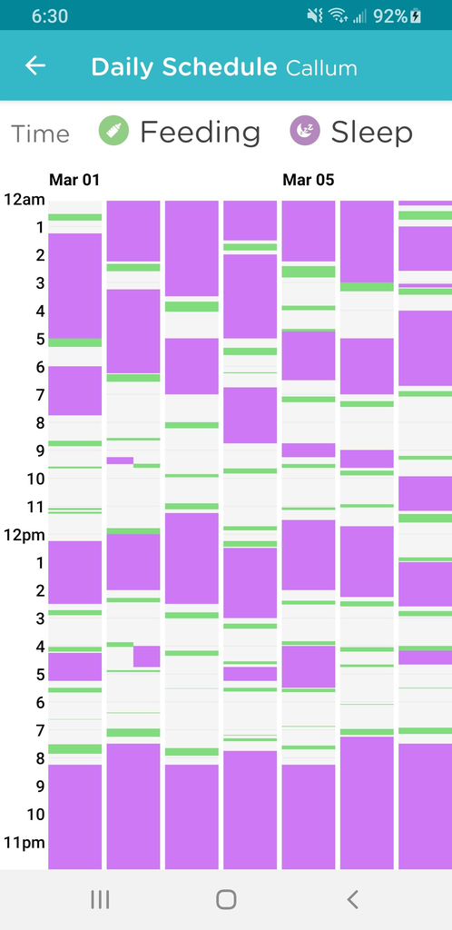

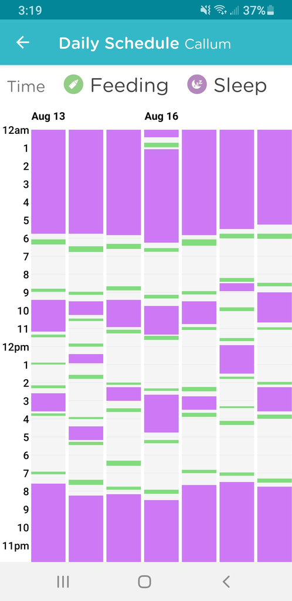

## 2.10 How we’d like it to work

https://xkcd.com/2400/

## 2.11 How it really works

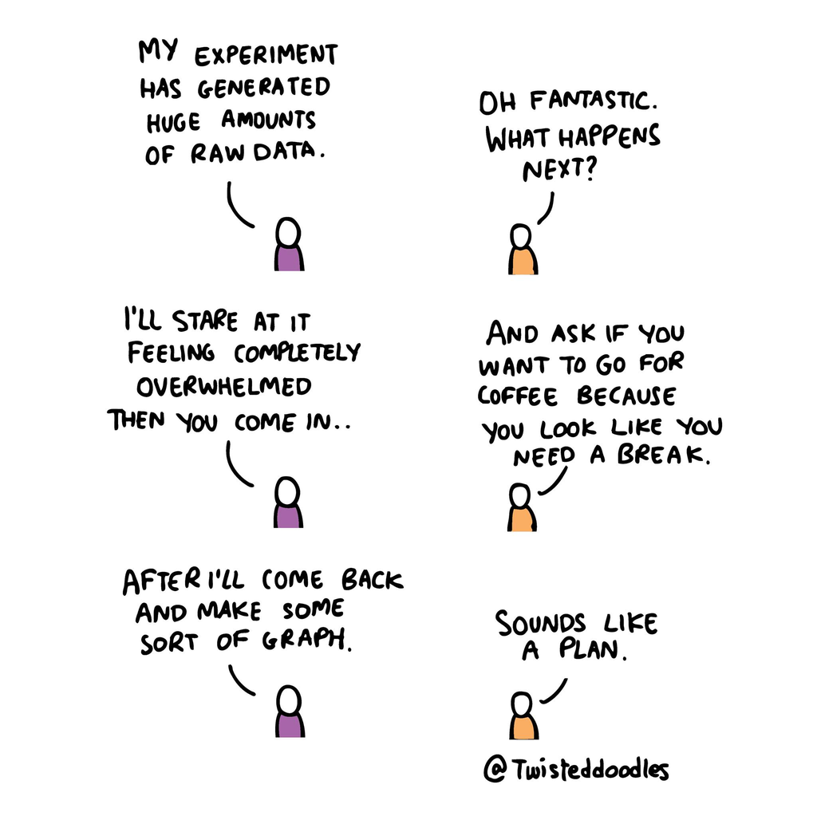

https://www.instagram.com/twisteddoodles/

# 3 Data

## 3.1 Data

- `ICU` data from the **Stat2Data** package
  - `ID`: Patient ID code
  - `Survive`: 1 = patient survived to discharge or 0 = patient died
  - `Age`: Age (in years)
  - `AgeGroup`: 1 = young (under 50), 2 = middle (50-69), 3 = old (70+)
  - `Sex`: 1 = female or 0 = male
  - `Infection`: 1 = infection suspected or 0 = no infection
  - `SysBP`: Systolic blood pressure (in mm of Hg)
  - `Pulse`: Heart rate (beats per minute)
  - `Emergency`: 1 = emergency admission or 0 = elective admission

## 3.2 Data

- Nominal / ordinal / factor / discrete / binary
  - `Survive`: 1 = patient survived to discharge or 0 = patient died
  - `Sex`: 1 = female or 0 = male
  - `Infection`: 1 = infection suspected or 0 = no infection
  - `Emergency`: 1 = emergency admission or 0 = elective admission
- Ordinal / factor / discrete
  - `AgeGroup`: 1 = young (under 50), 2 = middle (50-69), 3 = old (70+)

## 3.3 Data

- Ratio / integer / numeric / continuous
  - `Age`: Age (in years)
  - `SysBP`: Systolic blood pressure (in mm of Hg)
  - `Pulse`: Heart rate (beats per minute)

## 3.4 Data

```r
library(Stat2Data)
data(ICU)
head(ICU)
```

```
  ID Survive Age AgeGroup Sex Infection SysBP Pulse Emergency
1  4       0  87        3   1         1    80    96         1
2  8       1  27        1   1         1   142    88         1
3 12       1  59        2   0         0   112    80         1
4 14       1  77        3   0         0   100    70         0
5 27       0  76        3   1         1   128    90         1
6 28       1  54        2   0         1   142   103         1
```

## 3.5 Change variable types

```r
ICU$Survive <- as.factor(ICU$Survive)
ICU$Sex <- as.factor(ICU$Sex)
ICU$Infection <- as.factor(ICU$Infection)
ICU$Emergency <- as.factor(ICU$Emergency)
ICU$AgeGroup <- as.factor(ICU$AgeGroup)
```

- Default for factor variable categories is numerical order or alphabetical order
- Nothing we’re doing today *requires* this, but it *can* matter for more complex figures and if you want to do something really specific
  - You can also change the variable type within `ggplot()`

# 4 **ggplot2** package

## 4.1 **ggplot2** package

- Wilkinson, L. (2005). *The Grammar of Graphics (2nd ed.)*. Statistics and Computing, New York: Springer.
- Wickham, H. (2010). A layered grammar of graphics. *Journal of computational and graphical statistics, 19*(1), 3-28.
- Wickham, H. (2016). *ggplot2: elegant graphics for data analysis*. Springer.
- [Online documentation](https://ggplot2.tidyverse.org/reference/)

## 4.2 Grammar of graphics

- Grammar gives language rules. – Leland Wilkinson
- The grammar tells us what words make up our graphical “sentences,” but offers no advice on how to write well. – Hadley Wickham
  - “Colorless green ideas sleep furiously”

## 4.3 Grammar of graphics

- Data
- Variables
- Geometry
- Aesthetics
- Algebra
- Scales
- Statistics
- Coordinates
- Facets

## 4.4 `ggplot()` structure

```r
ggplot(data = DATA,
       aes(x = XVAR, y = YVAR)) +
       geom_MYGEOM() +
       geom_ANOTHERGEOM() +
       SOME_OTHER_THING +
       ANOTHER_THING
```

# 5 Plots for a single variable

## 5.1 Different kinds of plots

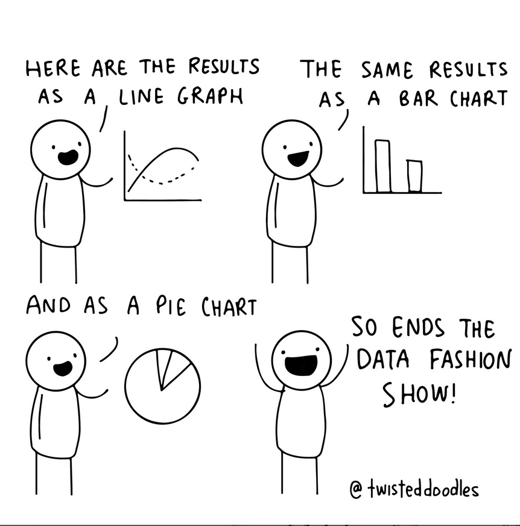

https://www.instagram.com/twisteddoodles/

## 5.2 One discrete: `geom_bar()`

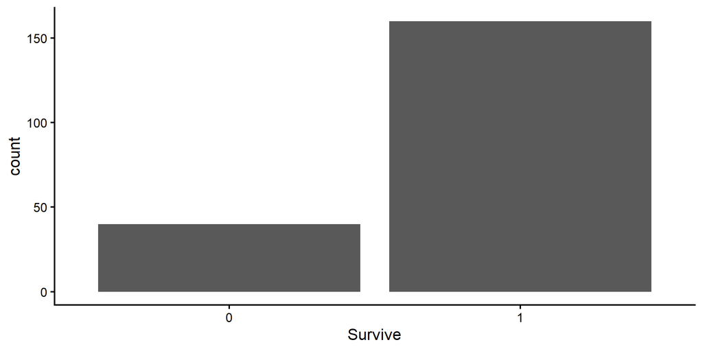

```r
ggplot(data = ICU,
       aes(x = Survive)) +
       geom_bar()
```

## 5.3 One discrete: `geom_bar()`

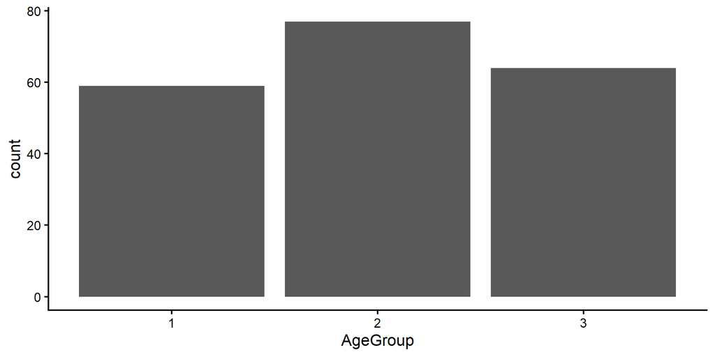

```r
ggplot(data = ICU,
       aes(x = AgeGroup)) +
       geom_bar()
```

## 5.4 One continuous: `geom_bar()`

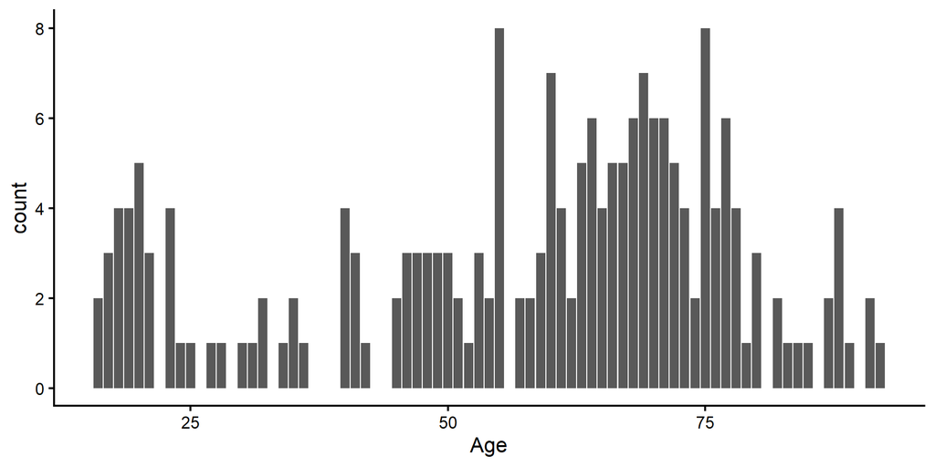

```r
ggplot(data = ICU,
       aes(x = Age)) +
       geom_bar()
```

## 5.5 One continuous: `geom_histogram()`

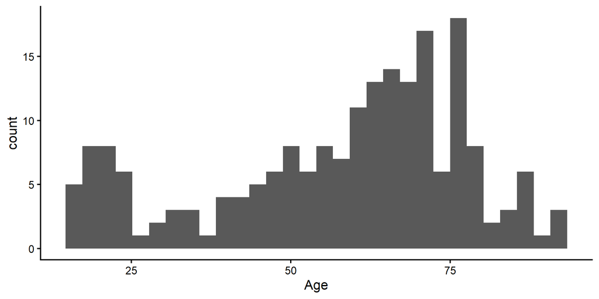

```r
ggplot(data = ICU,
       aes(x = Age)) +
       geom_histogram(bins = 30)
```

## 5.6 One continuous: `geom_histogram()`

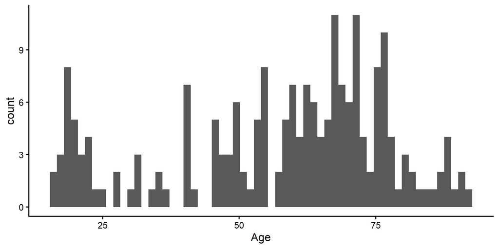

```r
ggplot(data = ICU,
       aes(x = Age)) +
       geom_histogram(bins = 60)
```

## 5.7 One continuous: `geom_histogram()`

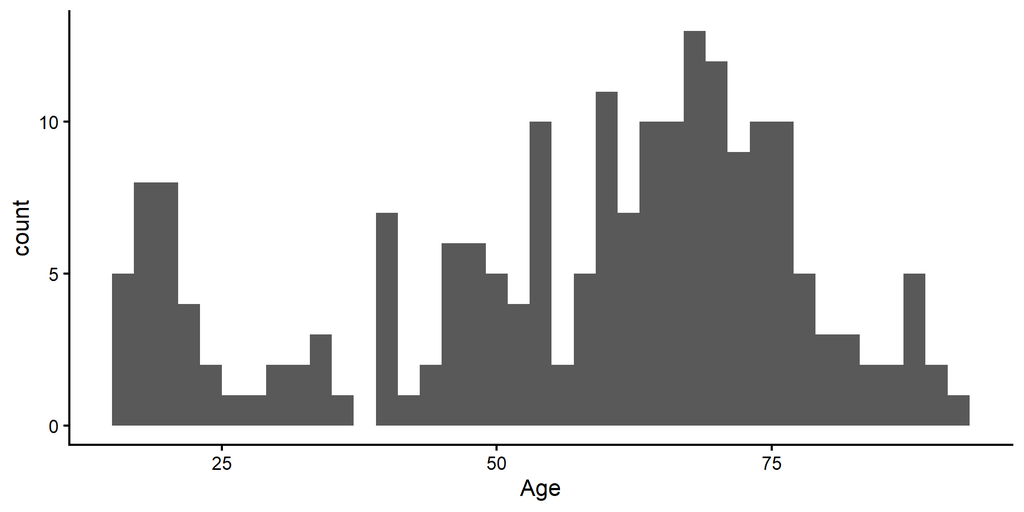

```r
ggplot(data = ICU,
       aes(x = Age)) +
       geom_histogram(binwidth = 2)
```

## 5.8 One continuous: `geom_dotplot()`

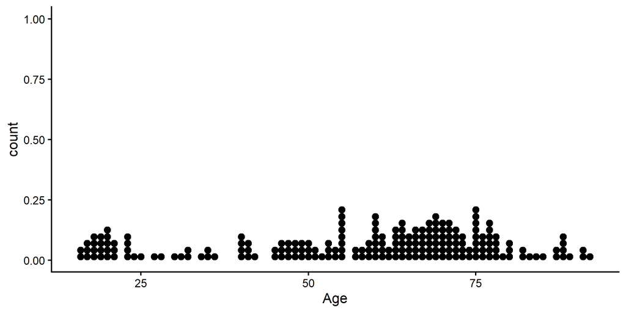

```r
ggplot(data = ICU,
       aes(x = Age)) +
       geom_dotplot(binwidth = 1)
```

## 5.9 One continuous: `geom_dotplot()`

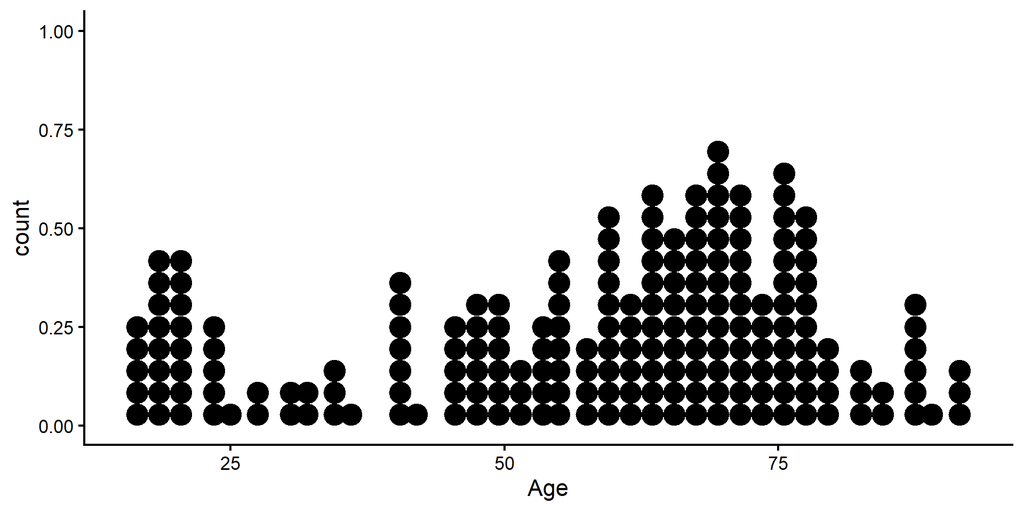

```r
ggplot(data = ICU,
       aes(x = Age)) +
       geom_dotplot(binwidth = 2)
```

## 5.10 One continuous: `geom_dotplot()`

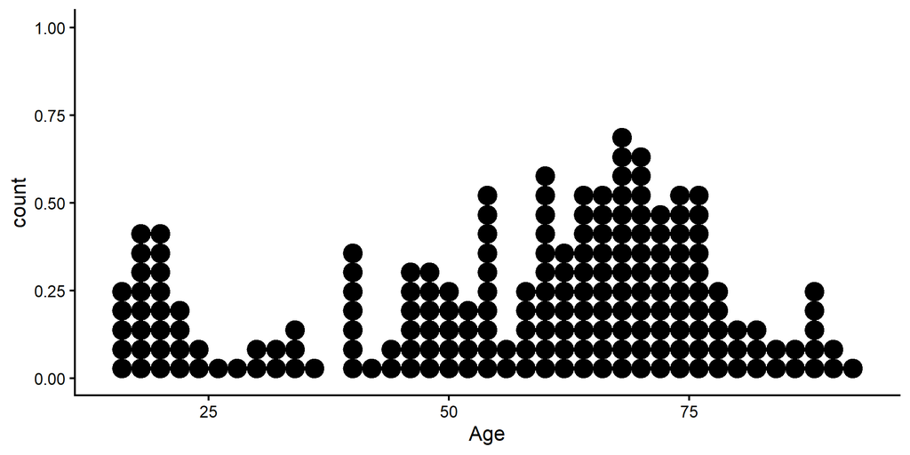

```r
ggplot(data = ICU,
       aes(x = Age)) +
       geom_dotplot(binwidth = 2,
                    method = "histodot")
```

## 5.11 One continuous: `geom_dotplot()`

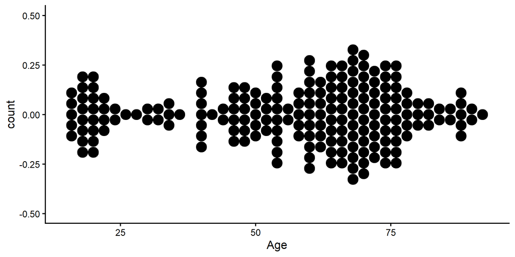

```r
ggplot(data = ICU,
       aes(x = Age)) +
       geom_dotplot(binwidth = 2,
                    method = "histodot",
                    stackdir = "center")
```

## 5.12 One continuous: `geom_density()`

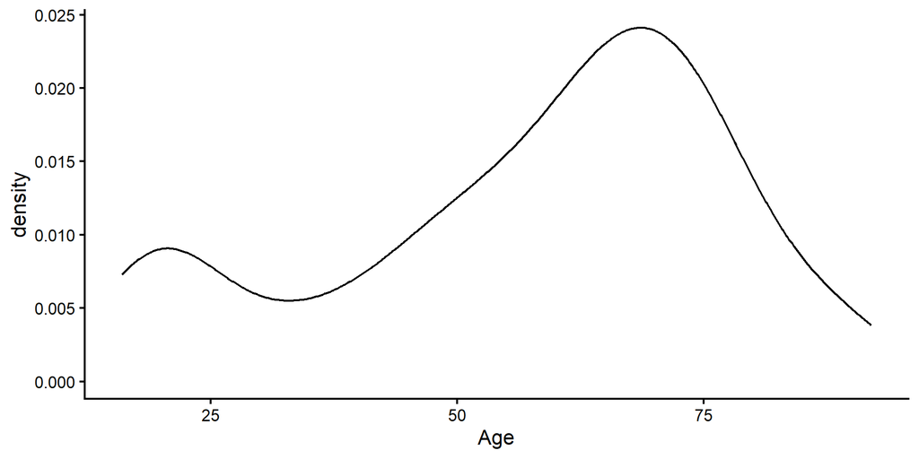

```r
ggplot(data = ICU,
       aes(x = Age)) +
       geom_density()
```

## 5.13 One continuous: `geom_violin()`

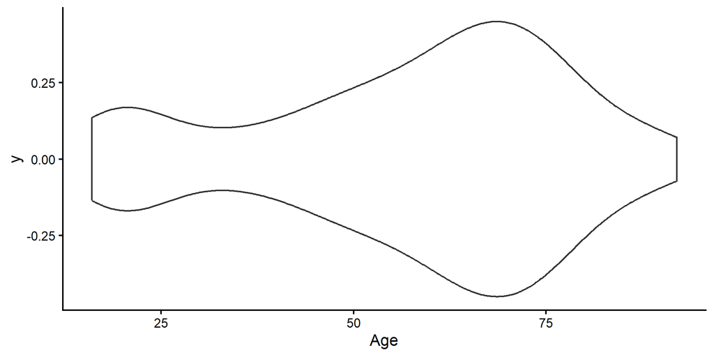

```r
ggplot(data = ICU,
       aes(x = Age)) +
       geom_violin(aes(y = 0))
```

## 5.14 One continuous: `violin` + `dotplot`

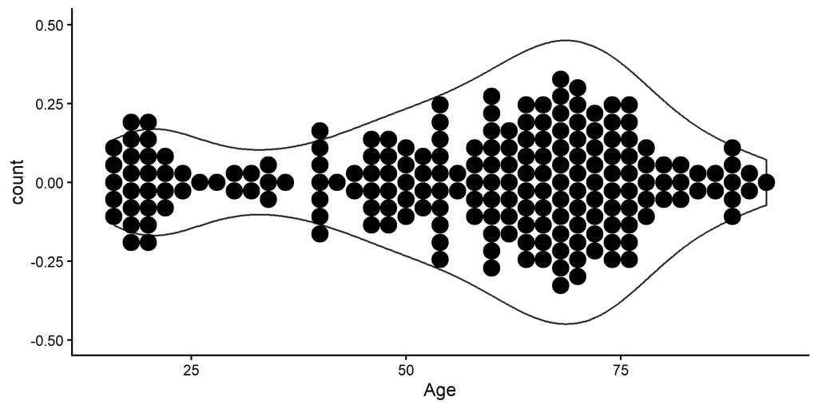

```r
ggplot(data = ICU,
       aes(x = Age)) +
       geom_violin(aes(y = 0)) +
       geom_dotplot(method = "histodot",
                    stackdir = "center",
                    binwidth = 2)
```

**Note**

`geom`s are layered in the order they’re listed. `geom_violin()` is opaque white (by default), so if you listed `geom_dotplot()` and then `geom_violin()`, the dots would be almost completely covered.

## 5.15 One continuous: `stat_qq`

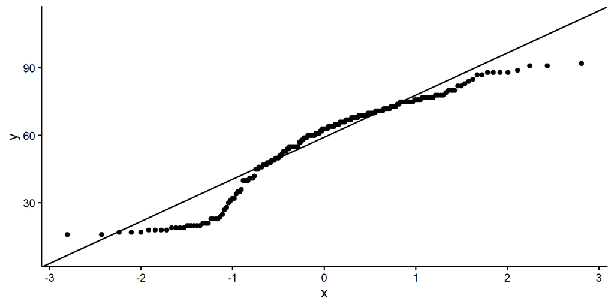

```r
ggplot(data = ICU,
       aes(sample = Age)) +
       stat_qq() +
       stat_qq_line()
```

# 6 Plots for two variables

## 6.1 Two discrete: `geom_count()`

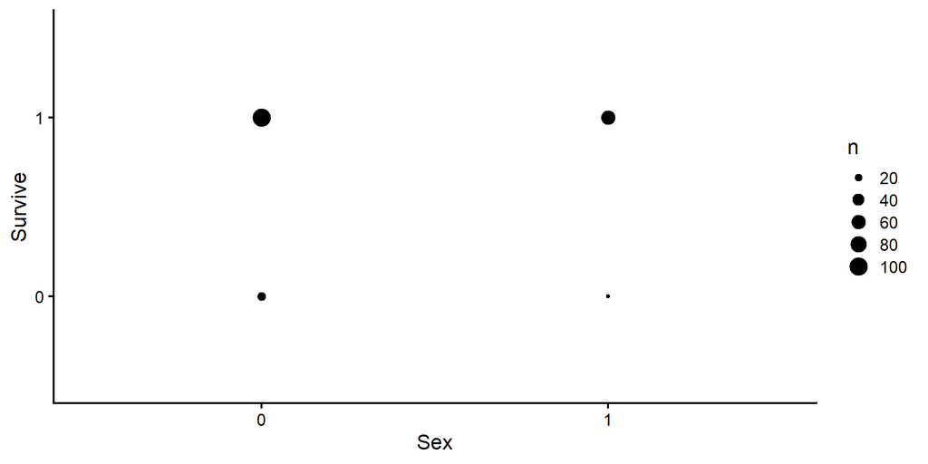

```r
ggplot(data = ICU,
       aes(x = Sex, y = Survive)) +
       geom_count()
```

## 6.2 Two discrete: `geom_jitter()`

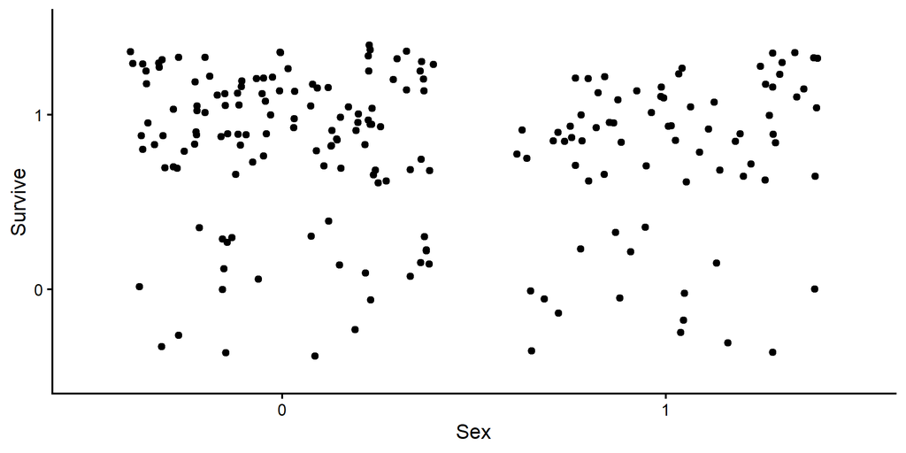

```r
ggplot(data = ICU,
       aes(x = Sex, y = Survive)) +
       geom_jitter()
```

## 6.3 Two discrete: `geom_jitter()`

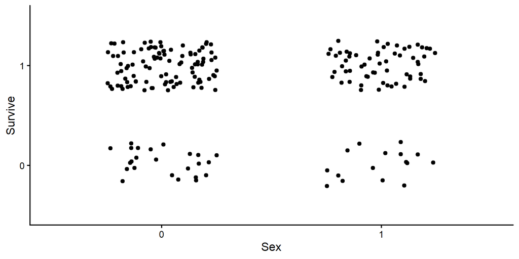

```r
ggplot(data = ICU,
       aes(x = Sex, y = Survive)) +
       geom_jitter(height = 0.25,
                   width = 0.25)
```

## 6.4 Two continuous: `geom_point()`

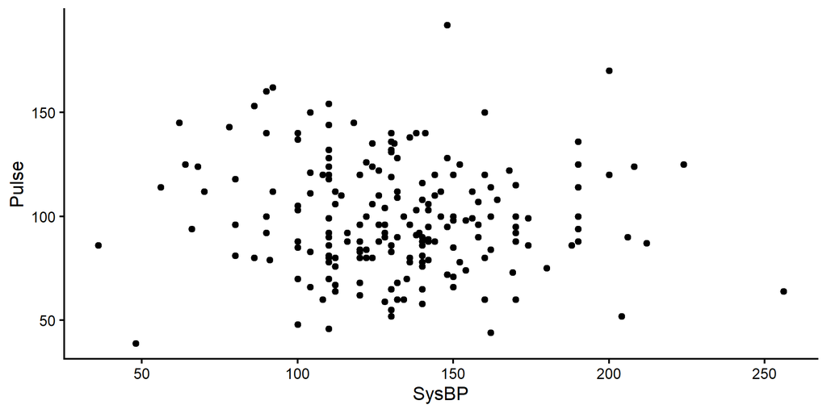

```r
ggplot(data = ICU,
       aes(x = SysBP, y = Pulse)) +
       geom_point()
```

## 6.5 Two continuous: `geom_smooth()`

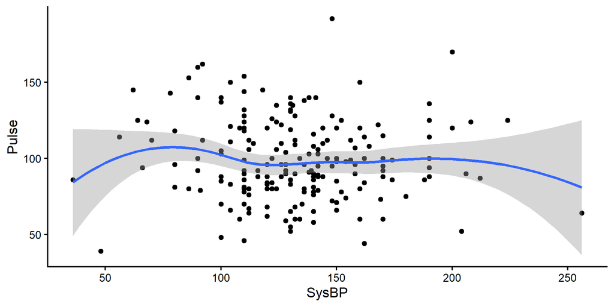

```r
ggplot(data = ICU,
       aes(x = SysBP, y = Pulse)) +
       geom_point() +
       geom_smooth()
```

## 6.6 Two continuous: `geom_smooth()`

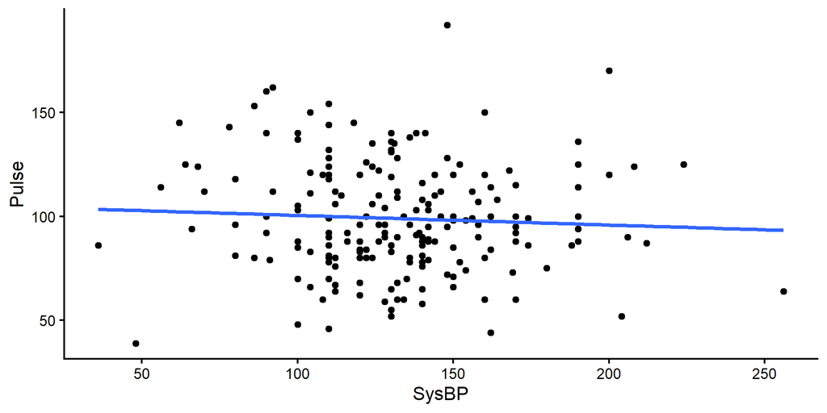

```r
ggplot(data = ICU,
       aes(x = SysBP, y = Pulse)) +
       geom_point() +
       geom_smooth(method = "lm",
                   se = FALSE)
```

## 6.7 One of each: `geom_col()`

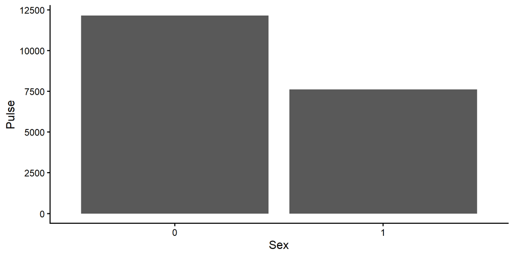

```r
ggplot(data = ICU,
       aes(x = Sex, y = Pulse)) +
       geom_col()
```

## 6.8 One of each: `geom_boxplot()`

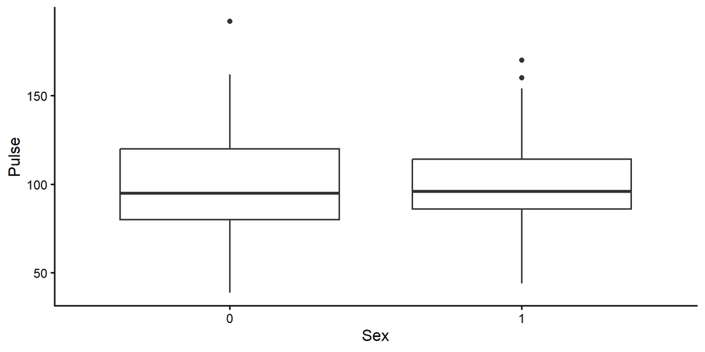

```r
ggplot(data = ICU,
       aes(x = Sex, y = Pulse)) +
       geom_boxplot()
```

## 6.9 One of each: `geom_dotplot()`

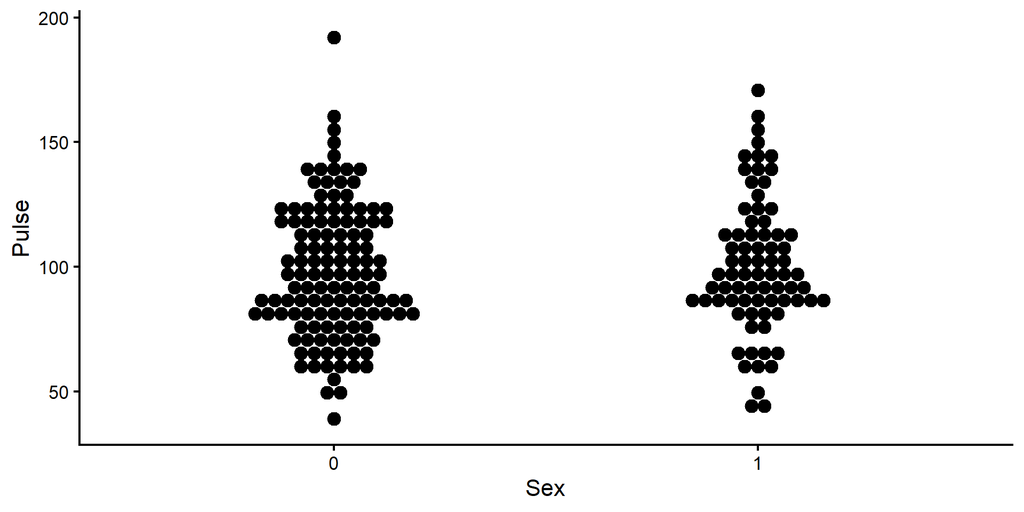

```r
ggplot(data = ICU,
       aes(x = Sex, y = Pulse)) +
       geom_dotplot(method = "histodot",
                    binaxis = "y",
                    stackdir = "center")
```

## 6.10 One of each: `geom_violin()`

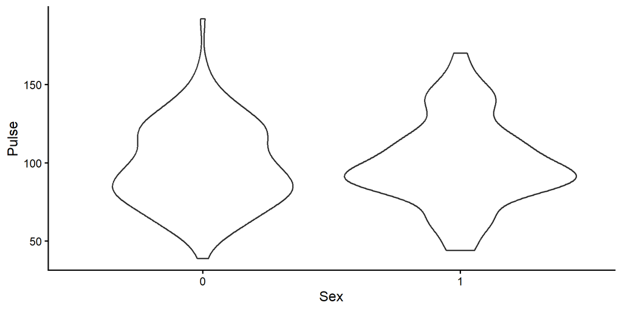

```r
ggplot(data = ICU,
       aes(x = Sex, y = Pulse)) +
       geom_violin()
```

## 6.11 One of each: `violin` + `dotplot`

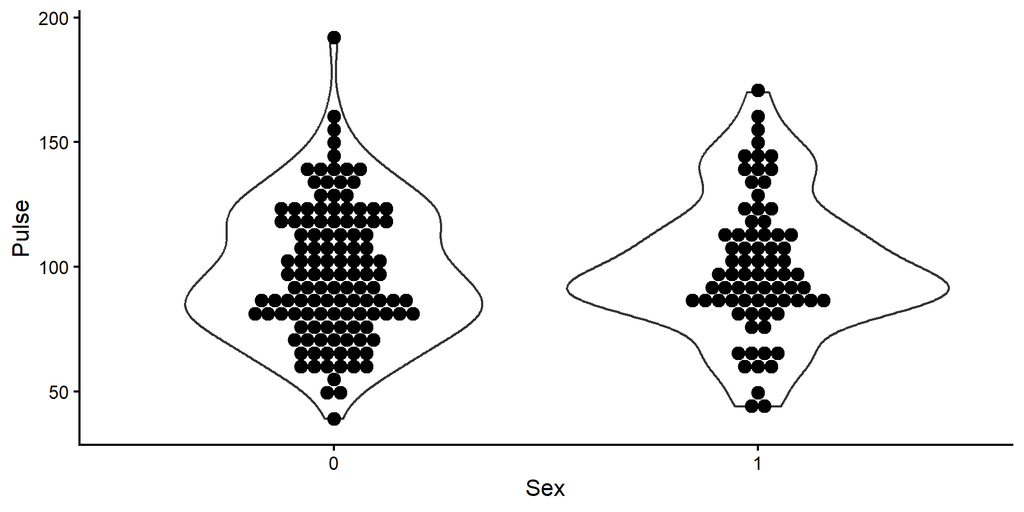

```r
ggplot(data = ICU,
       aes(x = Sex, y = Pulse)) +
       geom_violin() +
       geom_dotplot(method = "histodot",
                    binaxis = "y",
                    stackdir = "center")
```

# 7 A few more things

## 7.1 Vertical lines

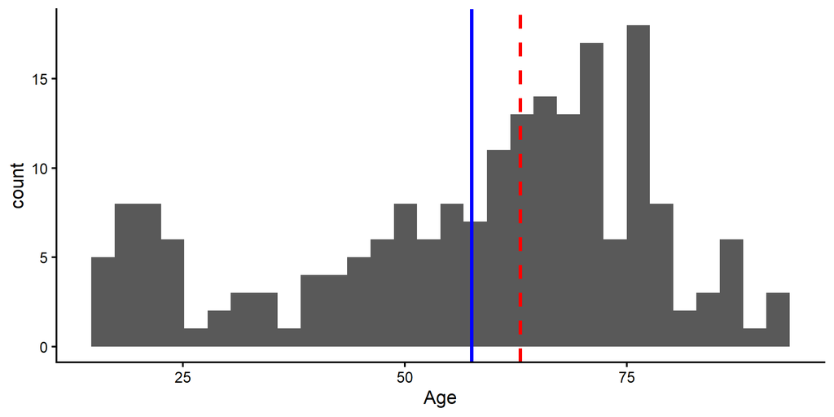

```r
ggplot(data = ICU,
       aes(x = Age)) +
       geom_histogram(bins = 30) +
       geom_vline(xintercept = mean(ICU$Age,
                                    na.rm = TRUE),
                  color = "blue",
                  linewidth = 1.5) +
       geom_vline(xintercept = median(ICU$Age,
                                      na.rm = TRUE),
                  color = "red",
                  linewidth = 1.5,
                  linetype = "dashed")
```